# Evaluative well-being

# 1 Description of DataSchema variable

The description of harmonised variable is the following:

- Short name: `evaluative_wb`
- Variable label: `Evaluative well-being`
- Variable description: `Evaluative well-being`
- Domain: `Health status and functional limitations`
- Value type: `Categorical`
- Category coding:

| **Code** | **Category Label** |
| --- | --- |
| 0 | Low |
| 1 | Middle |
| 2 | High |

- Category missings:

| **Code** | **Category Label** |
| --- | --- |
| 991 | CAPI/interviewer error |
| 992 | Impute |
| 993 | Disable to measure |
| 994 | Not attempt/not done |
| 995 | Does not answer |
| 996 | Not applicable |
| 997 | Refuse |
| 998 | Do not know |
| 999 | Missing |

# 2 Data process

## 2.1 England

### 2.1.1 Wave 1

There is no variable.

### 2.1.2 Wave 2

#### 2.1.2.1 Study-specific variable description

| **Name** | `sclifec` |
| --- | --- |
| **Label** | `The respondent is satisfied with their life` |
| **Table name** | `wave_2_core_data_v4` |
| **Categories** | `1 = Strongly agree` `2 = Agree` `3 = Slightly agree` `4 = Neither agree nor disagree` `5 = Slightly disagree` `6 = Disagree` `7 = Strongly disagree` |
| **Missings** | `-1 = Item not applicable` `-9 = Not answered` |
| **Description** |  |

sclifec

| Sample size | Missing values |
| --- | --- |
| 9432 | 1234 |

Category

|  | 1 | 2 | 3 | 4 | 5 | 6 | 7 |
| --- | --- | --- | --- | --- | --- | --- | --- |
| Frequency | 1499.00 | 4146.00 | 1182.00 | 544.00 | 378.00 | 332.00 | 117.00 |
| Percentage | 15.89 | 43.96 | 12.53 | 5.77 | 4.01 | 3.52 | 1.24 |

Missigns Categories

|  | -1 | -9 | NA |
| --- | --- | --- | --- |
| Frequency | 1072.00 | 162.00 | 0 |
| Percentage | 11.37 | 1.72 | 0 |

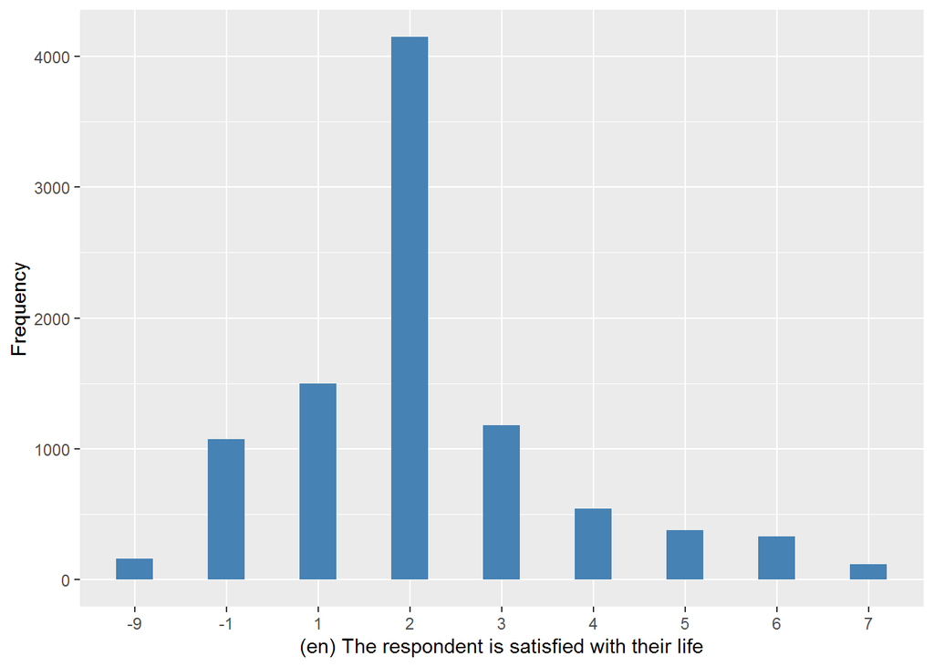

#### 2.1.2.2 Harmonisation algorithm

To compute the harmonize variable from the study-specific variable it has to be recoded as follows:

- `1,2 into 2`
- `3,4,5 into 1`
- `6,7 into 0`
- `-9 into 995`
- `-1 into 996`
- `NA into 999`

**R script:**

```r
ELSA_ds_w2 <- tibble(id=ELSA_wb$id)
ELSA_ds_w2$evaluative_wb <- car::recode(ELSA_wb$sclifec, "1=2; 3=1; 4=1; 5=1; 6=0; 7=0; -9=995; -1=996; NA=999")
```

#### 2.1.2.3 Statistical description of the new harmonised variable

Evaluative well-being

| Sample size | Missing values |
| --- | --- |
| 9432 | 1234 |

Category

|  | 0 | 1 | 2 |
| --- | --- | --- | --- |
| Frequency | 449.00 | 2104.00 | 5645.00 |
| Percentage | 4.76 | 22.31 | 59.85 |

Type of missing

|  | 991 | 992 | 993 | 994 | 995 | 996 | 997 | 998 | 999 | NA |
| --- | --- | --- | --- | --- | --- | --- | --- | --- | --- | --- |
| Frequency | 0 | 0 | 0 | 0 | 162.00 | 1072.00 | 0 | 0 | 0 | 0 |
| Percentage | 0 | 0 | 0 | 0 | 1.72 | 11.37 | 0 | 0 | 0 | 0 |

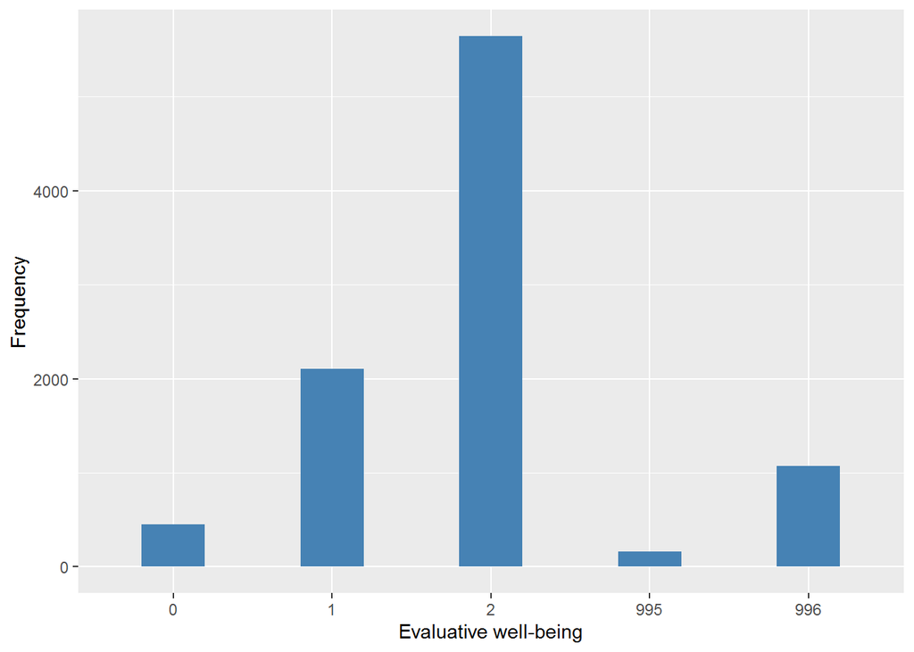

#### 2.1.2.4 Validation

### 2.1.3 Wave 3

#### 2.1.3.1 Study-specific variable description

| **Name** | `sclifec` |
| --- | --- |
| **Label** | `Is satisfied with his/her life` |
| **Table name** | `wave_3_elsa_data_v4` |
| **Categories** | `1 = Strongly agree` `2 = Agree` `3 = Slightly agree` `4 = Neither agree nor disagree` `5 = Slightly disagree` `6 = Disagree` `7 = Strongly disagree` |
| **Missings** | `-1 = Item not applicable` `-8 = Don't know` `-9 = Not answered` |
| **Description** |  |

sclifec

| Sample size | Missing values |
| --- | --- |
| 9771 | 1651 |

Category

|  | 1 | 2 | 3 | 4 | 5 | 6 | 7 |
| --- | --- | --- | --- | --- | --- | --- | --- |
| Frequency | 900.00 | 4005.00 | 1261.00 | 668.00 | 658.00 | 448.00 | 180.00 |
| Percentage | 9.21 | 40.99 | 12.91 | 6.84 | 6.73 | 4.58 | 1.84 |

Missigns Categories

|  | -1 | -8 | -9 | NA |
| --- | --- | --- | --- | --- |
| Frequency | 1527.00 | 0 | 124.00 | 0 |
| Percentage | 15.63 | 0 | 1.27 | 0 |

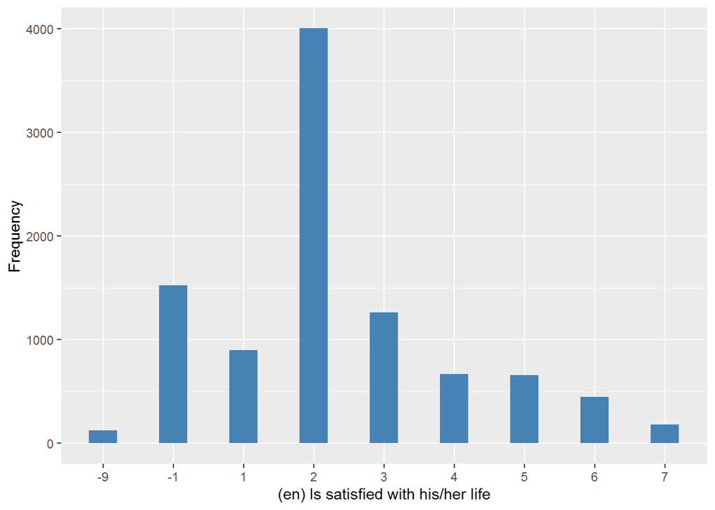

#### 2.1.3.2 Harmonisation algorithm

To compute the harmonize variable from the study-specific variable it has to be recoded as follows:

- `1,2 into 2`
- `3,4,5 into 1`
- `6,7 into 0`
- `-9 into 995`
- `-8 into 998`
- `-1 into 996`
- `NA into 999`

**R script:**

```r
ELSA_ds_w3 <- tibble(id=ELSA_wb$id)
ELSA_ds_w3$evaluative_wb <- car::recode(ELSA_wb$sclifec, "1=2; 3=1; 4=1; 5=1; 6=0; 7=0; -9=995; -8=998; -1=996; NA=999")
```

#### 2.1.3.3 Statistical description of the new harmonised variable

Evaluative well-being

| Sample size | Missing values |
| --- | --- |
| 9771 | 1651 |

Category

|  | 0 | 1 | 2 |
| --- | --- | --- | --- |
| Frequency | 628.00 | 2587.00 | 4905.0 |
| Percentage | 6.43 | 26.48 | 50.2 |

Type of missing

|  | 991 | 992 | 993 | 994 | 995 | 996 | 997 | 998 | 999 | NA |
| --- | --- | --- | --- | --- | --- | --- | --- | --- | --- | --- |
| Frequency | 0 | 0 | 0 | 0 | 124.00 | 1527.00 | 0 | 0 | 0 | 0 |
| Percentage | 0 | 0 | 0 | 0 | 1.27 | 15.63 | 0 | 0 | 0 | 0 |

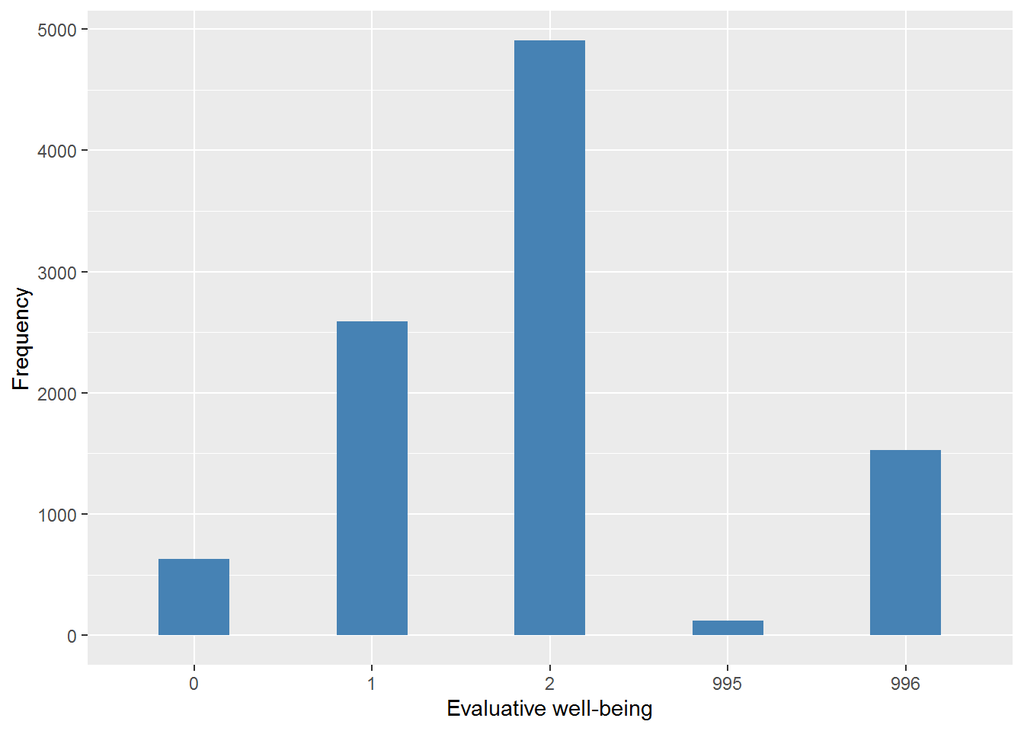

#### 2.1.3.4 Validation

### 2.1.4 Wave 4

| **Name** | `sclifec` |
| --- | --- |
| **Label** | `Is satisfied with his/her life` |
| **Table name** | `wave_4_elsa_data_v3` |
| **Categories** | `1 = Strongly agree` `2 = Agree` `3 = Slightly agree` `4 = Neither agree nor disagree` `5 = Slightly disagree` `6 = Disagree` `7 = Strongly disagree` |
| **Missings** | `-1 = Item not applicable` `-8 = Don't know` `-9 = Not answered` |
| **Description** |  |

sclifec

| Sample size | Missing values |
| --- | --- |
| 11050 | 1860 |

Category

|  | 1 | 2 | 3 | 4 | 5 | 6 | 7 |
| --- | --- | --- | --- | --- | --- | --- | --- |
| Frequency | 1215 | 4492.00 | 1609.00 | 724.00 | 560.00 | 416.00 | 174.00 |
| Percentage | 11 | 40.65 | 14.56 | 6.55 | 5.07 | 3.76 | 1.57 |

Missigns Categories

|  | -1 | -8 | -9 | NA |
| --- | --- | --- | --- | --- |
| Frequency | 1708.00 | 0 | 152.00 | 0 |
| Percentage | 15.46 | 0 | 1.38 | 0 |

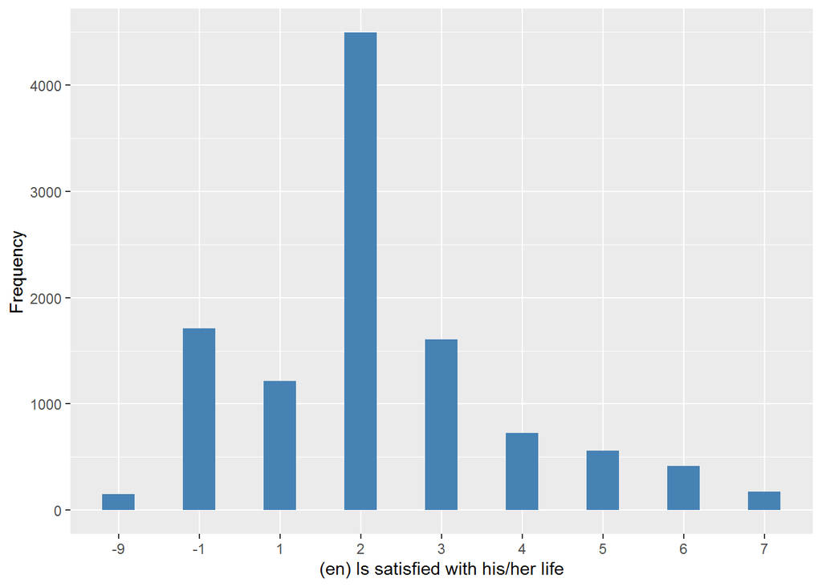

#### 2.1.4.1 Harmonisation algorithm

To compute the harmonize variable from the study-specific variable it has to be recoded as follows:

- `1,2 into 2`
- `3,4,5 into 1`
- `6,7 into 0`
- `-9 into 995`
- `-8 into 998`
- `-1 into 996`
- `NA into 999`

**R script:**

```r
ELSA_ds_w4 <- tibble(id=ELSA_wb$id)
ELSA_ds_w4$evaluative_wb <- car::recode(ELSA_wb$sclifec, "1=2; 3=1; 4=1; 5=1; 6=0; 7=0; -9=995; -8=998; -1=996; NA=999")
```

#### 2.1.4.2 Statistical description of the new harmonised variable

Evaluative well-being

| Sample size | Missing values |
| --- | --- |
| 11050 | 1860 |

Category

|  | 0 | 1 | 2 |
| --- | --- | --- | --- |
| Frequency | 590.00 | 2893.00 | 5707.00 |
| Percentage | 5.34 | 26.18 | 51.65 |

Type of missing

|  | 991 | 992 | 993 | 994 | 995 | 996 | 997 | 998 | 999 | NA |
| --- | --- | --- | --- | --- | --- | --- | --- | --- | --- | --- |
| Frequency | 0 | 0 | 0 | 0 | 152.00 | 1708.00 | 0 | 0 | 0 | 0 |
| Percentage | 0 | 0 | 0 | 0 | 1.38 | 15.46 | 0 | 0 | 0 | 0 |

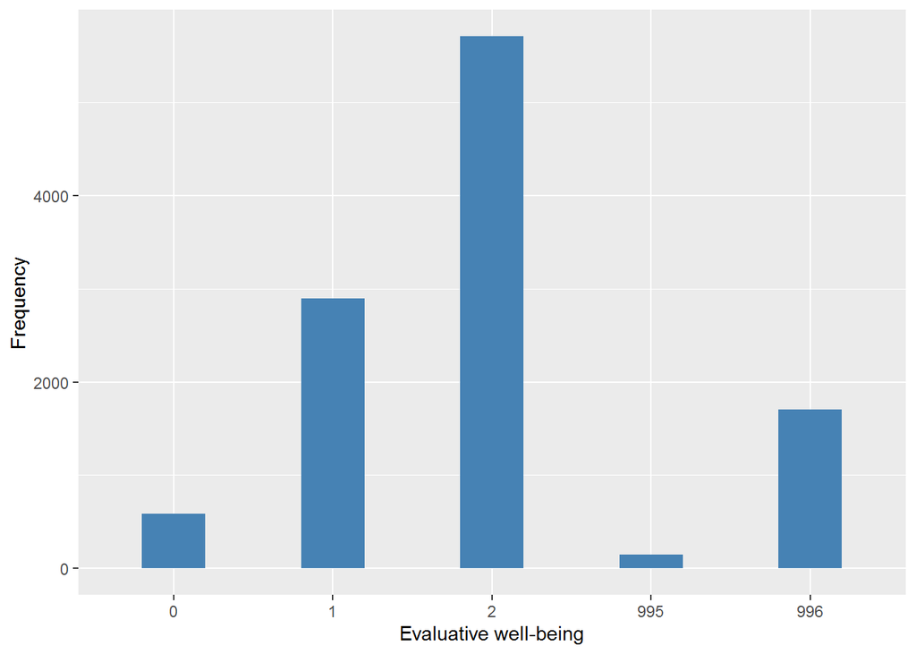

#### 2.1.4.3 Validation

### 2.1.5 Wave 5

#### 2.1.5.1 Study-specific variable description

| **Name** | `sclifec` |
| --- | --- |
| **Label** | `Is satisfied with his/her life` |
| **Table name** | `wave_5_elsa_data_v4` |
| **Categories** | `1 = Strongly agree` `2 = Agree` `3 = Slightly agree` `4 = Neither agree nor disagree` `5 = Slightly disagree` `6 = Disagree` `7 = Strongly disagree` |
| **Missings** | `-1 = Item not applicable` `-2 = Schedule Not Applicable` `-8 = Don't know` `-9 = Not answered` |
| **Description** |  |

sclifec

| Sample size | Missing values |
| --- | --- |
| 10274 | 1410 |

Category

|  | 1 | 2 | 3 | 4 | 5 | 6 | 7 |
| --- | --- | --- | --- | --- | --- | --- | --- |
| Frequency | 1448.00 | 4279.00 | 1396.00 | 624.00 | 532.00 | 446.00 | 139.00 |
| Percentage | 14.09 | 41.65 | 13.59 | 6.07 | 5.18 | 4.34 | 1.35 |

Missigns Categories

|  | -1 | -2 | -8 | -9 | NA |
| --- | --- | --- | --- | --- | --- |
| Frequency | 0 | 1244.00 | 0 | 166.00 | 0 |
| Percentage | 0 | 12.11 | 0 | 1.62 | 0 |

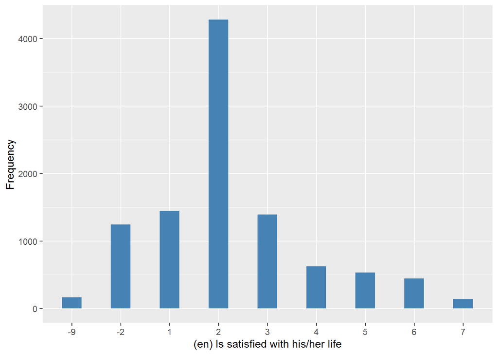

#### 2.1.5.2 Harmonisation algorithm

To compute the harmonize variable from the study-specific variable it has to be recoded as follows:

- `1,2 into 2`
- `3,4,5 into 1`
- `6,7 into 0`
- `-9 into 995`
- `-8 into 998`
- `-2 into 996`
- `-1 into 996`
- `NA into 999`

**R script:**

```r
ELSA_ds_w5 <- tibble(id=ELSA_wb$id)
ELSA_ds_w5$evaluative_wb <- car::recode(ELSA_wb$sclifec, "1=2; 3=1; 4=1; 5=1; 6=0; 7=0; -9=995; -8=998; -2=996; -1=996; NA=999")
```

#### 2.1.5.3 Statistical description of the new harmonised variable

Evaluative well-being

| Sample size | Missing values |
| --- | --- |
| 10274 | 1410 |

Category

|  | 0 | 1 | 2 |
| --- | --- | --- | --- |
| Frequency | 585.00 | 2552.00 | 5727.00 |
| Percentage | 5.69 | 24.84 | 55.74 |

Type of missing

|  | 991 | 992 | 993 | 994 | 995 | 996 | 997 | 998 | 999 | NA |
| --- | --- | --- | --- | --- | --- | --- | --- | --- | --- | --- |
| Frequency | 0 | 0 | 0 | 0 | 166.00 | 1244.00 | 0 | 0 | 0 | 0 |
| Percentage | 0 | 0 | 0 | 0 | 1.62 | 12.11 | 0 | 0 | 0 | 0 |

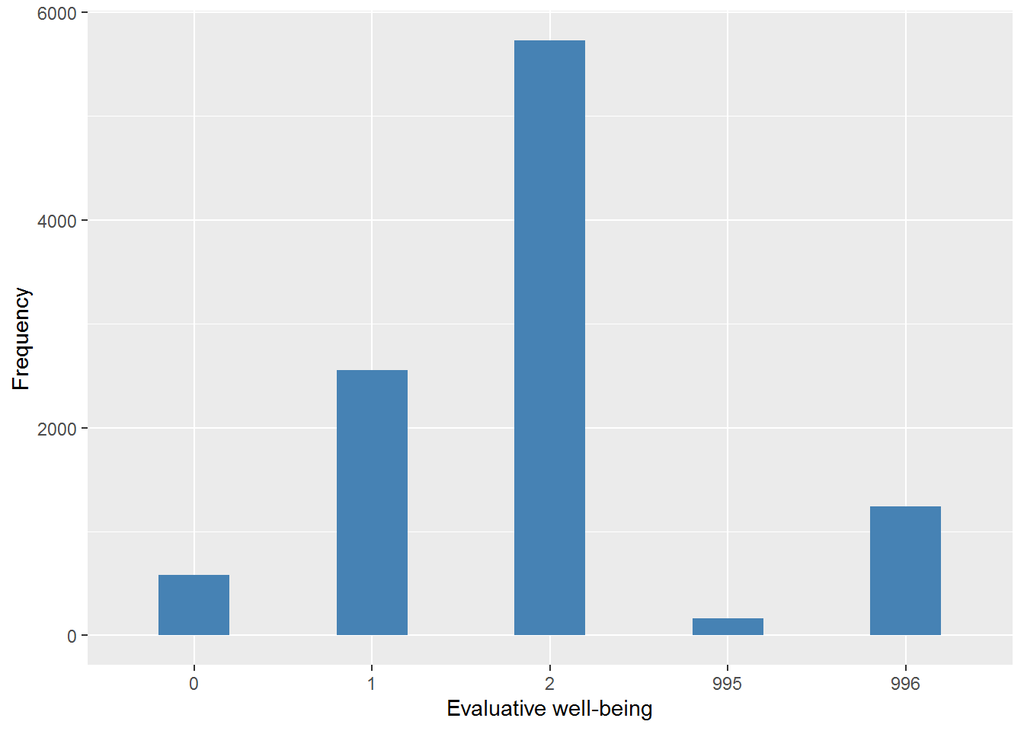

#### 2.1.5.4 Validation

### 2.1.6 Wave 6

#### 2.1.6.1 Study-specific variable description

| **Name** | `sclifec` |
| --- | --- |
| **Label** | `Is satisfied with his/her life` |
| **Table name** | `wave_6_elsa_data_v2` |
| **Categories** | `1 = Strongly agree` `2 = Agree` `3 = Slightly agree` `4 = Neither agree nor disagree` `5 = Slightly disagree` `6 = Disagree` `7 = Strongly disagree` |
| **Missings** | `-1 = Item not applicable` `-2 = Schedule Not Applicable` `-8 = Don't know` `-9 = Not answered` |
| **Description** |  |

sclifec

| Sample size | Missing values |
| --- | --- |
| 10601 | 1763 |

Category

|  | 1 | 2 | 3 | 4 | 5 | 6 | 7 |
| --- | --- | --- | --- | --- | --- | --- | --- |
| Frequency | 1299.00 | 4096.00 | 1492.00 | 750.00 | 588.00 | 458.00 | 155.00 |
| Percentage | 12.25 | 38.64 | 14.07 | 7.07 | 5.55 | 4.32 | 1.46 |

Missigns Categories

|  | -1 | -2 | -8 | -9 | NA |
| --- | --- | --- | --- | --- | --- |
| Frequency | 0 | 1604.00 | 0 | 159.0 | 0 |
| Percentage | 0 | 15.13 | 0 | 1.5 | 0 |

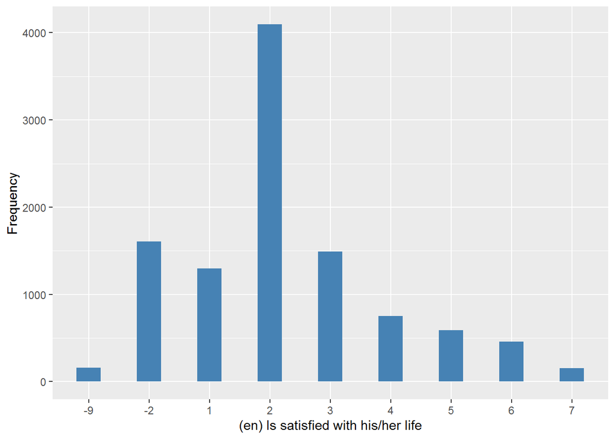

#### 2.1.6.2 Harmonisation algorithm

To compute the harmonize variable from the study-specific variable it has to be recoded as follows:

- `1,2 into 2`
- `3,4,5 into 1`
- `6,7 into 0`
- `-9 into 995`
- `-8 into 998`
- `-2 into 996`
- `-1 into 996`
- `NA into 999`

**R script:**

```r
ELSA_ds_w6 <- tibble(id=ELSA_wb$id)
ELSA_ds_w6$evaluative_wb <- car::recode(ELSA_wb$sclifec, "1=2; 3=1; 4=1; 5=1; 6=0; 7=0; -9=995; -8=998; -2=996; -1=996; NA=999")
```

#### 2.1.6.3 Statistical description of the new harmonised variable

Evaluative well-being

| Sample size | Missing values |
| --- | --- |
| 10601 | 1763 |

Category

|  | 0 | 1 | 2 |
| --- | --- | --- | --- |
| Frequency | 613.00 | 2830.0 | 5395.00 |
| Percentage | 5.78 | 26.7 | 50.89 |

Type of missing

|  | 991 | 992 | 993 | 994 | 995 | 996 | 997 | 998 | 999 | NA |
| --- | --- | --- | --- | --- | --- | --- | --- | --- | --- | --- |
| Frequency | 0 | 0 | 0 | 0 | 159.0 | 1604.00 | 0 | 0 | 0 | 0 |
| Percentage | 0 | 0 | 0 | 0 | 1.5 | 15.13 | 0 | 0 | 0 | 0 |

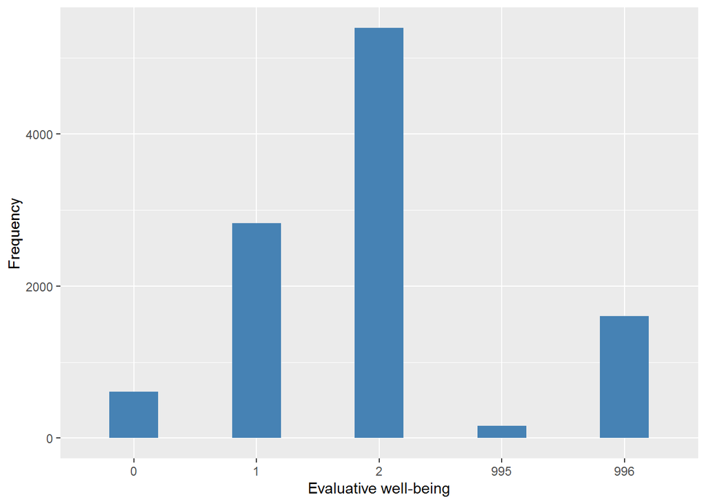

#### 2.1.6.4 Validation

### 2.1.7 Wave 7

#### 2.1.7.1 Study-specific variable description

| **Name** | `sclifec` |
| --- | --- |
| **Label** | `Is satisfied with his/her life` |
| **Table name** | `wave_7_elsa_data` |
| **Categories** | `1 = Strongly agree` `2 = Agree` `3 = Slightly agree` `4 = Neither agree nor disagree` `5 = Slightly disagree` `6 = Disagree` `7 = Strongly disagree` |
| **Missings** | `-1 = Item not applicable` `-2 = Schedule Not Applicable` `-8 = Don't know` `-9 = Not answered` |
| **Description** |  |

sclifec

| Sample size | Missing values |
| --- | --- |
| 9666 | 1655 |

Category

|  | 1 | 2 | 3 | 4 | 5 | 6 | 7 |
| --- | --- | --- | --- | --- | --- | --- | --- |
| Frequency | 1300.00 | 3867.00 | 1251.00 | 670.00 | 469.00 | 313.00 | 141.00 |
| Percentage | 13.45 | 40.01 | 12.94 | 6.93 | 4.85 | 3.24 | 1.46 |

Missigns Categories

|  | -1 | -2 | -8 | -9 | NA |
| --- | --- | --- | --- | --- | --- |
| Frequency | 0 | 1469.0 | 0 | 186.00 | 0 |
| Percentage | 0 | 15.2 | 0 | 1.92 | 0 |

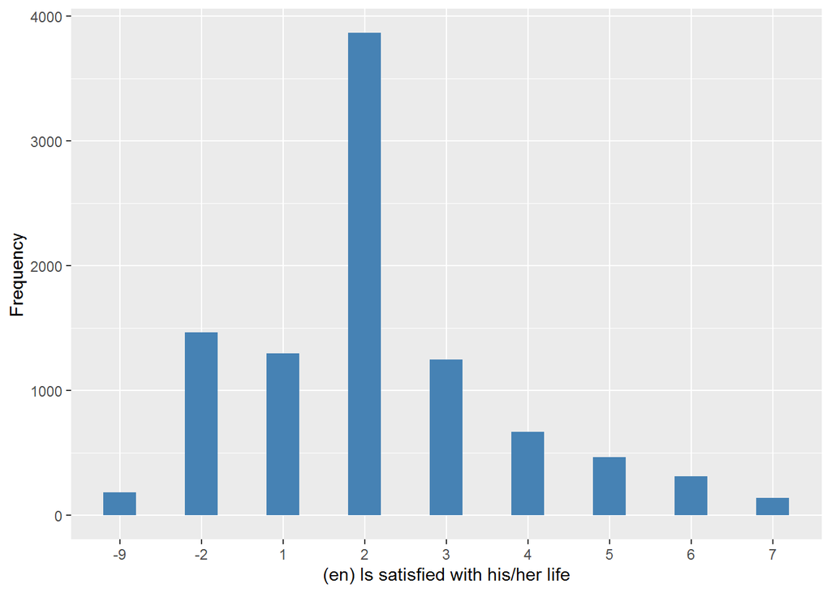

#### 2.1.7.2 Harmonisation algorithm

To compute the harmonize variable from the study-specific variable it has to be recoded as follows:

- `1,2 into 2`
- `3,4,5 into 1`
- `6,7 into 0`
- `-9 into 995`
- `-8 into 998`
- `-2 into 996`
- `-1 into 996`
- `NA into 999`

**R script:**

```r
ELSA_ds_w7 <- tibble(id=ELSA_w7$id)
ELSA_ds_w7$evaluative_wb <- car::recode(ELSA_w7$sclifec, "1=2; 3=1; 4=1; 5=1; 6=0; 7=0; -9=995; -8=998; -2=996; -1=996; NA=999")
```

#### 2.1.7.3 Statistical description of the new harmonised variable

Evaluative well-being

| Sample size | Missing values |
| --- | --- |
| 9666 | 1655 |

Category

|  | 0 | 1 | 2 |
| --- | --- | --- | --- |
| Frequency | 454.0 | 2390.00 | 5167.00 |
| Percentage | 4.7 | 24.73 | 53.46 |

Type of missing

|  | 991 | 992 | 993 | 994 | 995 | 996 | 997 | 998 | 999 | NA |
| --- | --- | --- | --- | --- | --- | --- | --- | --- | --- | --- |
| Frequency | 0 | 0 | 0 | 0 | 186.00 | 1469.0 | 0 | 0 | 0 | 0 |
| Percentage | 0 | 0 | 0 | 0 | 1.92 | 15.2 | 0 | 0 | 0 | 0 |

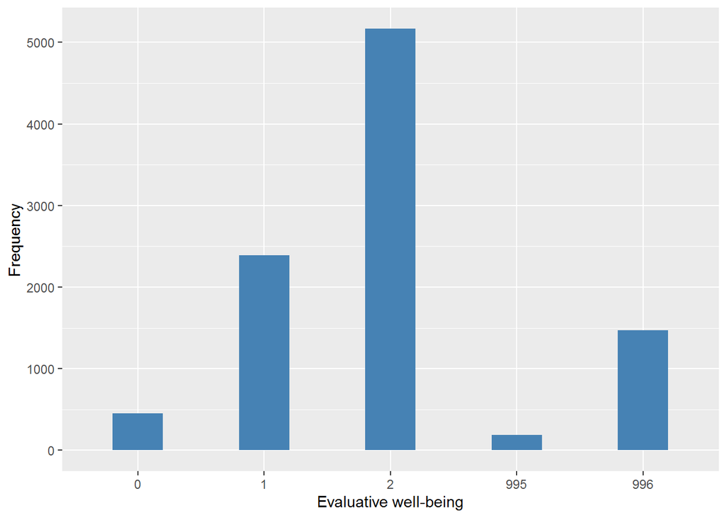

#### 2.1.7.4 Validation

## 2.2 Summary of descriptive statistics of the harmonised variable accross populations and waves

Evaluative well-being

| val | label | W2 | W3 | W4 | W5 | W6 | W7 |
| --- | --- | --- | --- | --- | --- | --- | --- |
| 0 | Low | 4.76 | 6.43 | 5.34 | 5.69 | 5.78 | 4.7 |
| 1 | Middle | 22.31 | 26.48 | 26.18 | 24.84 | 26.7 | 24.73 |
| 2 | High | 59.85 | 50.2 | 51.65 | 55.74 | 50.89 | 53.46 |
| 991 | CAPI interviewer error | 0 | 0 | 0 | 0 | 0 | 0 |
| 992 | Impute | 0 | 0 | 0 | 0 | 0 | 0 |
| 993 | Disable to measure | 0 | 0 | 0 | 0 | 0 | 0 |
| 994 | Not attempt not done | 0 | 0 | 0 | 0 | 0 | 0 |
| 995 | Does not answer | 1.72 | 1.27 | 1.38 | 1.62 | 1.5 | 1.92 |
| 996 | Not applicable | 11.37 | 15.63 | 15.46 | 12.11 | 15.13 | 15.2 |
| 997 | Refuse | 0 | 0 | 0 | 0 | 0 | 0 |
| 998 | Do not know | 0 | 0 | 0 | 0 | 0 | 0 |
| 999 | Missing | 0 | 0 | 0 | 0 | 0 | 0 |
| n | sample size | 9432 | 9771 | 11050 | 10274 | 10601 | 9666 |

# 3 Quality estimation